# Лабораторная работа 3. Задания

Дроздовская Полина

10/02/2024

# Задача

Рассмотрим телекоммуникационную сеть, состоящую из $p$ узлов-маршрутизаторов $R$ и $q$ соединяющих их линий связи $P$. Каждая линия связи оценивается временем задержки сигнала измеряемым в миллисекундах:
$$W=\{w_1,w_2,...,w_q\}$$
Маршрутизаторы, имеют горячее резервирование кратности:
$$SR=\{sr_1,sr_2,...,sr_p\}\\ 1\leq sr_i\leq
5$$
Линии связи имеют дублирование кратности:
$$SP=\{sp_1,sp_2,...,sp_q\}\\ 1\leq sp_i\leq
5$$
Для высококритичных приложений, например, для военной техники, обязателен резерв канала боевого управления, а скорость передачи данных оказывает существенное влияние на отклик системы в целом. Требуется найти два (в общем случае можно рассматривать $r$) зарезервированных канала от узла $k$ к узлу $l$, не задействующих совместно незадублированные маршрутизаторы и линии связи, обеспечивающих суммарно минимальное время задержки.

# Указания к решению.

1. Найти все $N$ не образующие петель маршруты $Rt$ от узла $k$ к узлу $l$. Это можно сделать вручную. На высокую оценку необходимо разработать и реализовать алгоритм, осуществляющий построение таких маршрутов. Допускается использование библиотечной функции.
2. Занумеруем все возможные маршруты от $1$ до $n$ и сопоставим каждому из них соответствующее время задержки $t_i$, равное сумме времен по всем ребрам маршрута $i$.
3. Введем в качестве варьируемых параметров бинарные переменные $x_i$, $i=1,...,n$. Здесь $x_i=1$, если маршрут номер $i$ выбран и $x_i=0$, если нет. Тогда целевая функция, которую необходимо минимизировать, будет иметь вид:
   $$F(\vec{x})=\sum_{i=1}^{N}t_ix_i\\$$
   Так как необходимо найти $r$ независимых каналов, первое ограничение имеет вид (в простейшем случае для двукратного резервирования $r=2$):
   $$\sum_{i=1}^{N}x_i=r$$
4. Далее требуется построить ограничение ресурсов для маршрутов. Столбцами матрыцы ограничений будут маршруты, а по строкам задействованные маршрутизаторы и линии связи. Следовательно, для всех маршрутов использующих совместно маршрутизатор (линию связи) можно записать ограничение:
   $$\sum_{i\in V(Rt)} x_i
   \leq SR\\ \sum_{i\in E(Rt)} x_i \leq SP$$

   В теории графов для графа $g$ множество его вершин обозначается как $V(g)$, а множество его рёбер $E(g)$.
5. Решаем задачу линейного целочисленного программирования.
6. Построить граф с выделенными найденными маршрутами.

# Варианты

Введите ваше ФИО в параметр функции **digest2int**

```r
library(digest)
library(extraDistr)
set.seed(digest2int('Дроздовская Полина Кирилловна'))
```

Переменная *simple* отвечает за выбор варианта сложности.

```r
simple <- TRUE
```

Далее на основании вашего ФИО и варианта сложности генерируются основные параметры задачи. Число маршрутизаторов $p$:

```r
p <- ifelse(simple, rdunif(1,6,10), rdunif(1,25,50))
p
```

```
## [1] 10
```

Число резервных маршрутов $r$

```r
r <- ifelse(simple,2,rdunif(1,3,5))
r
```

```
## [1] 2
```

Граф маршрутизации

```r
library(igraph)
repeat
{
g <<- sample_gnp(p, ifelse(simple,0.2,0.05))
if(is_connected(g))
  break
}
```

Количество линий связи $q$

```r
q <- length(E(g))
q
```

```
## [1] 17
```

Задержка линии связи $W$

```r
E(g)$weight <- rdunif(q,1,100)
```

Резервирование маршрутизаторов $SR$

```r
V(g)$standby <- if(simple) rep(2,p) else rdunif(p,r,5)
```

Резервирование линий связи $SP$

```r
E(g)$standby <- if(simple) rep(2,q) else rdunif(q,r,5)
```

Узлы, между которыми требуется обеспечить надежную связь

```r
v <- farthest_vertices(g)$vertices
v
```

```
## + 2/10 vertices, from 7717b8d:
## [1] 1 6
```

```r
k <- v[1]
l <- v[2]
```

```r
paths <- all_simple_paths(g, k, l)
length(paths)
```

```
## [1] 68
```

```r
paths[[4]]
```

```
## + 7/10 vertices, from 7717b8d:
## [1] 1 3 2 7 5 4 6
```

# Ваш вариант

Общая формулировка задачи выглядит следующим образом **(подстановка реализуется при сохранении, например html)**:

Рассмотрим телекоммуникационную сеть, состоящую из $p=10$ узлов-маршрутизаторов $R$ и $q=17$ соединяющих их линий связи $P$. Сеть определяется граформ, заданным списком смежности:
$$\newcommand\ue{\mathrel{\bullet\mkern-3mu{-}\mkern-3mu\bullet}}
\{1\ue3,2\ue3,2\ue5,4\ue5,4\ue6,2\ue7,3\ue7,4\ue7,5\ue7,3\ue8,6\ue8,1\ue9,2\ue9,3\ue9,4\ue9,1\ue10,\\9\ue10\}$$
Каждая линия связи оценивается временем задержки сигнала измеряемым в миллисекундах:
$$W=\{36,66,5,50,34,38,66,62,10,75,45,34,26,9,63,68,3\}$$
Маршрутизаторы, имеют горячее резервирование кратности:
$$SR=\{2\}$$
Линии связи имеют дублирование кратности:
$$SP=\{2\}$$
Требуется найти $r=2$ зарезервированных канала от узла $k=1$ к узлу $l=6$, не задействующих совместно незадублированные маршрутизаторы и линии связи, обеспечивающих суммарно минимальное время задержки.

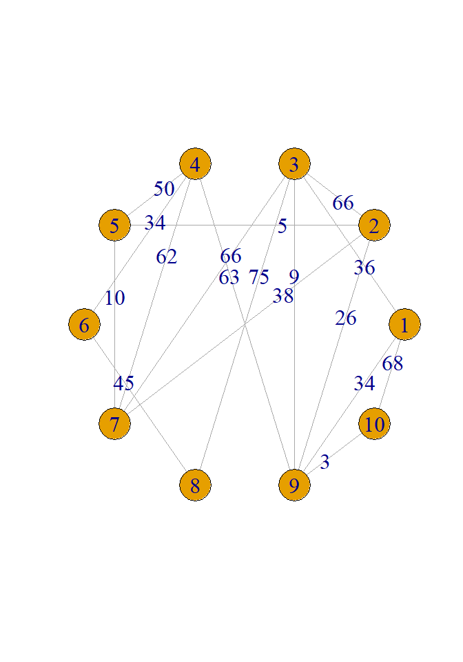

# Оценивание

4-6 Поиск маршрутов вручную, задание ограничений вручную, простой вариант.

6-8 Автоматический поиск маршрутов, автоматическое или ручное задание ограничений, простой вариант.

8-10 Автоматическое решение общей задачи, отсутсвие явных циклов (используйте функции *apply), продвинутая индексация.